# Uppföljning Dalastrategin

### Könssegregering

**Könssegrering i olika branscher och uttag av föräldrapenning**

Sedan många år har kvinnor och män haft likvärdig tillgång till utbildning och möjlighet att fritt välja yrke. Trots detta består många av könsskillnaderna i arbetslivet, och står därmed i vägen för en mer hållbar utveckling där människor och kompetens tas tillvara på ett mer objektivt sätt.

*Könssegregering i olika branscher*

Många branscher i länet har idag en tydlig övervikt av det ena eller det andra könet, exempelvis byggbranschen som omfattar yrken inom bland annat el och VVS, och där kvinnor bara utgör ungefär 10 procent av de förvärvsarbetande. Även om det har skett en ökning av andelen kvinnor inom byggbranschen är denna ökning ännu liten i sammanhanget. Inom vård och omsorg är bilden densamma men med motsatt könsfördelning. Här utgör kvinnor cirka 77 procent av de förvärvsarbetande.

Att åstadkomma en förändring i närtid av balansen mellan män och kvinnor inom de könssegregerade branscherna förefaller inte vara inom räckhåll då ungdomars studieval fortsätter att vara könsstereotypa.

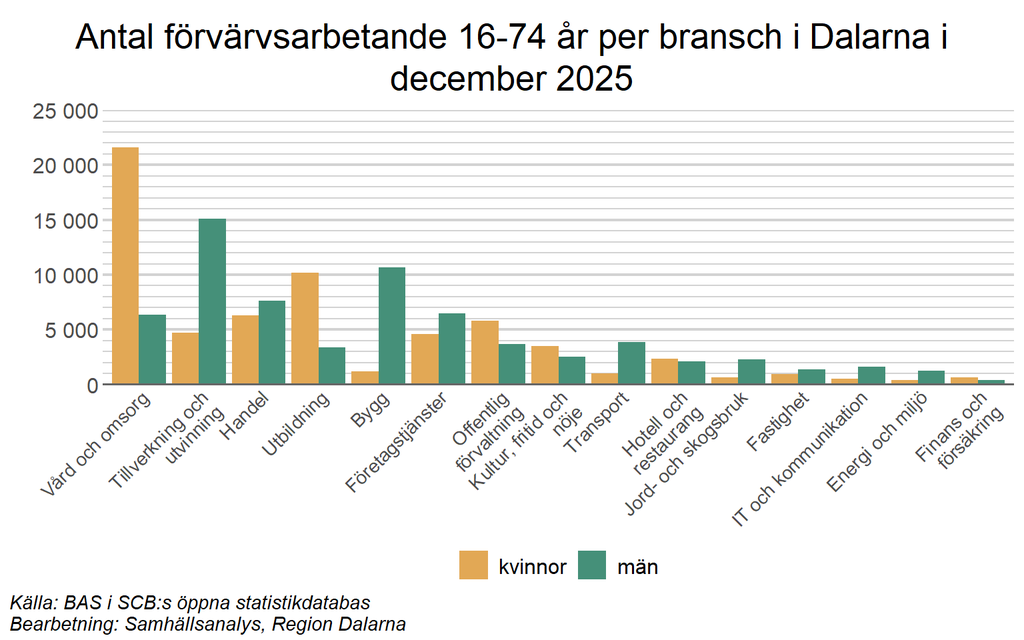

*Föräldrapenning*

Fördelningen av dagar mellan vårdnadshavarna har jämnats ut något sedan slutet av 1990-talet då runt 85-90 procent av föräldrapenningdagarna togs ut av mammorna. Sedan dess har först en (1995), sedan två (2002) och även tre månader (2016) reserverats åt respektive vårdnadshavare (också kallade “pappamånader”). Detta har bidragit till ett jämnare uttag men utvecklingen får ändå sägas gå relativt trögt, då kvinnors andel endast har minskat till runt 69 procent 2025. Svenska vårdnadshavare är således långt ifrån att ge sina barn en jämställd tillgång till sina föräldrar. Skillnaden i uttag påverkar också den disponibla inkomsten. Skillnaden är som störst mellan sammanboende kvinnor och män när det yngsta barnet är 0–3 år [(Regeringen, 2022)](https://www.regeringen.se/contentassets/46945970585240a4a5bfd9a0f75ecf3d/ekonomisk-jamstalldhet.pdf).

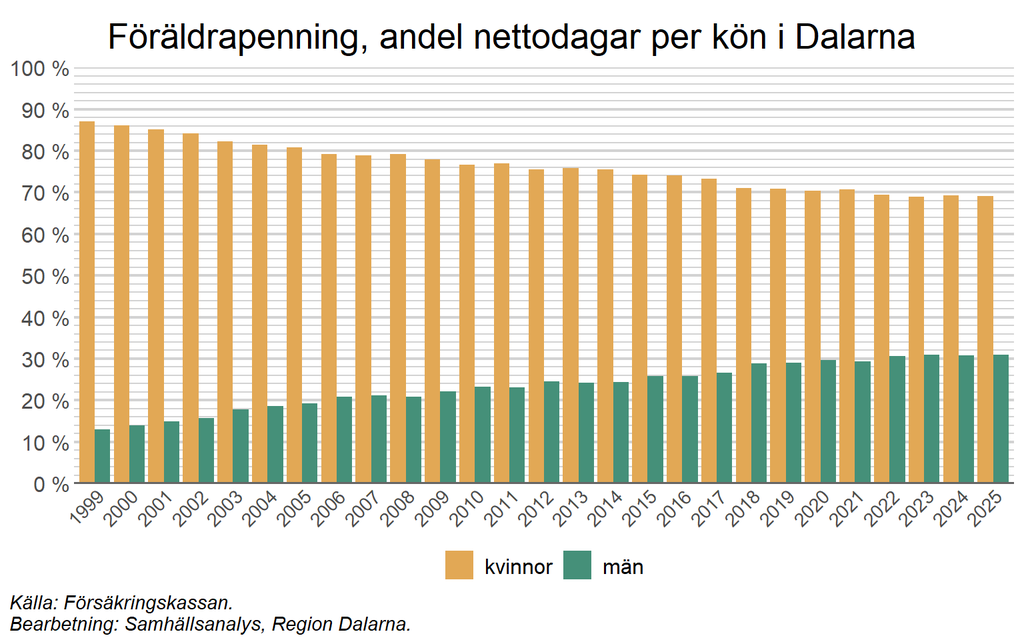

### Företagsklimat och infrastruktur

**Företagsklimat och infrastruktur**

*Företagsklimat*

*Tågens punktlighet*

### Ekobrottslighet

**Ekonomisk brottslighet**

Ekonomisk brottslighet drabbar företag i Dalarna genom att den skapar osund konkurrens och förskjuter villkoren för dem som följer reglerna. När aktörer fuskar med skatter och avgifter, använder falska fakturor, utnyttjar arbetskraft eller missbrukar bolagsformer kan de pressa priserna på ett sätt som seriösa företag inte kan matcha. För enskilda företag innebär det risk för direkta ekonomiska förluster, mer administration och ökade kostnader för kontroll, samt att affärsrelationer och leverantörskedjor blir mer osäkra. På längre sikt undergräver brottsligheten tilliten i näringslivet, minskar viljan att investera och kan göra det svårare att rekrytera och växa. Ett starkt lokalt näringsliv gynnas därför av tydliga spelregler, samverkan och förebyggande arbete som minskar utrymmet för fusk och bedrägerier.

Ekonomisk brottslighet omfattar bokföringsbrott och bidragsbrott så som förskingring och bedrägerier. “Enligt Skatteverket har det totala skattefelet länge minskat, det vill säga summan av de skatter som inte redovisas till följd av bland annat brott. Samtidigt verkar utvecklingen gå mot en mer förslagen skattebrottslighet.” [“Brå, 2026”](https://bra.se/amnen/ekonomisk-brottslighet)

På riksnivå har antalet anmälda brott per 100 000 invånare ökat från ca 2 200 till ca 3 000, mellan åren 2014 och 2024. I Dalarna ligger således antalet anmälda brott betydligt lägre än i riket som helhet, men det är enligt diagrammet nedan också betydande skillnader mellan kommunerna inom länet, med Avesta på cirka 1 400 anmälda brott och Vansbro på under 450 anmälda brott per 100 000 invånare år 2024.

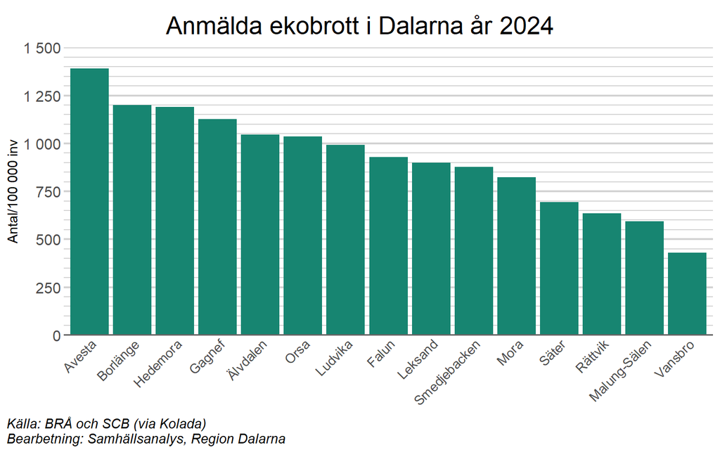

## 2.3 Ekonomiska värden, produktion och export

Företagens produktion skapar ekonomiska värden som genererar löner och vinster och är centrala på Dalarnas konkurrenskraft. När företag kan producera effektivt och skapa högt värde på sina varor och tjänster stärks både lönsamhet och produktivitet, vilket ger utrymme för innovation och nya jobb. Exporten visar hur väl Dalarnas näringsliv står sig på nationella och internationella marknader och bidrar samtidigt till regionala inkomster och en starkare skattebas. I det här avsnittet belyser vi produktionens utveckling och exportens omfattning, men även hur kvinnors och mäns inkomster utvecklas, då inkomster är en viktig förutsättning för ekonomisk självständighet och grunden för skatteintäkter.

Regional arbetsproduktivitet ➡  
Produktiviteten i länet avtar, medan den ökar i riket totalt sett.

Regionala inkomster ➡  
Medianinkomsterna ökar, och lite mer för kvinnor, men män tjänar fortfarande betydligt mer.

Regional export ➡  
Både den regionala varuexporten och exportintäkter från utländska turister ökar.

### Arbetsproduktivitet

**Regional arbetsproduktivitet**

Värdet av den samlade produktionen i länet mäts genom bruttoregionalprodukten. Ett sätt att fånga om ekonomin växer är att räkna om värdet per sysselsatt, också kallat arbetsproduktivitet, ökar över tid.

BRP är ett mått på det samlade värdet av alla varor och tjänster som produceras i länet under ett år. BRP ger en övergripande bild av ekonomins storlek och tillväxt och kan användas för att följa konjunkturförändringar och långsiktiga trender. Utvecklingen av värdet påverkas av både befolkningsutveckling och näringslivets struktur.

Vid jämförelser över tid är även BRP per invånare viktigt att följa då den samlade produktionen ska försörja samtliga i samhället, och om arbetskåren krymper relativt unga och äldre, ska färre försörja fler.

Diagrammen nedan visar utvecklingen av bruttoregionalprodukten (BRP) i Dalarna per sysselsatt i löpande priser. Värdet används för att bedöma arbetsproduktiviteten, det vill säga om varje anställd producerar lika mycket, mer eller mindre i jämförelse med föregående år. Tillväxt skapas när arbetet genererar ökande värden. Det är tydligt att värdet av produktionen på riksnivå ökar i större volym än i Dalarna, och att arbetsproduktiviteten i Dalarna är bland de lägre i landet.

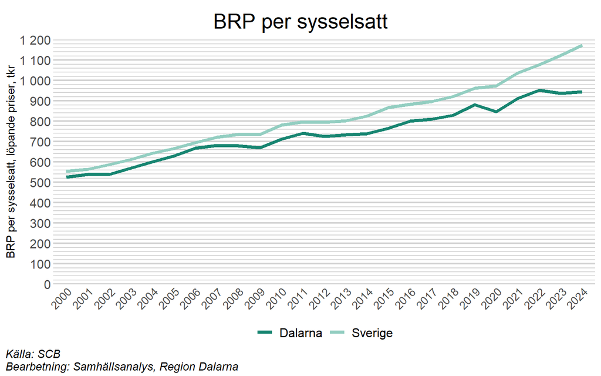

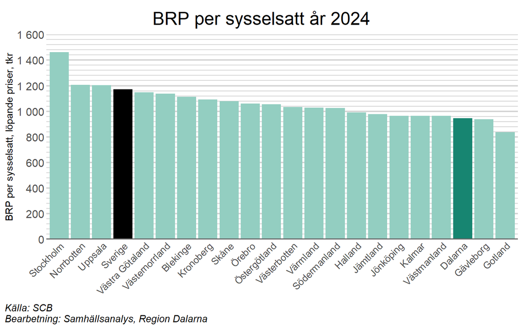

### Inkomster

**Kvinnors och mäns inkomster**

En egen inkomst är en av förutsättningarna för ett ekonomiskt självständigt liv. Livsinkomsten påverkar även vilken pension personen kommer att få efter arbetslivet. Ett centralt syfte med jämställdhetspolitiken är att motverka att arbetsinsatser värderas olika enbart på grund av vem som utför dem.

För kvinnor och män i Dalarna i arbetsför ålder (20-64 år) är inkomstskillnaderna relativt stora och skillnaderna har hållit i sig över tid. Medianinkomsten för en man i Dalarna var 2024 cirka 427 tusen kronor före skatt, medan en kvinna hade en medianinkomst på ungefär 355 tusen kronor. I den andra figuren nedan syns även en positiv utveckling i form av att den relativa skillnaden i inkomst mellan könen har minskat sedan millennieskiftet. Diagrammet visar att kvinnors medianinkomst har ökat med 118 procent sedan slutet millennieskiftet, medan mäns har ökat med ungefär 99 procent. Det är dock viktigt att notera att figurerna nedan endast redovisar kvinnors och mäns skilda ekonomiska förutsättningar, medan det kan finnas flera förklaringar till skillnaden. En faktor är att kvinnor i högre grad arbetar deltid, och därför kan ha en lägre årsinkomst. Men även yrke, bransch och utbildningsinriktning kan förklara en del av skillnaden.

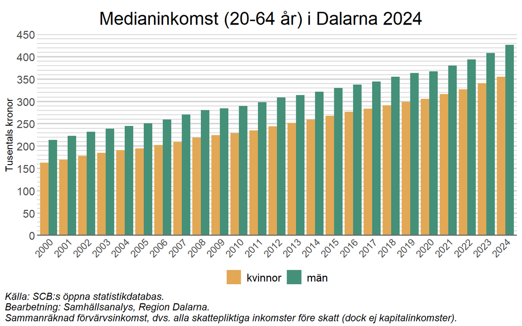

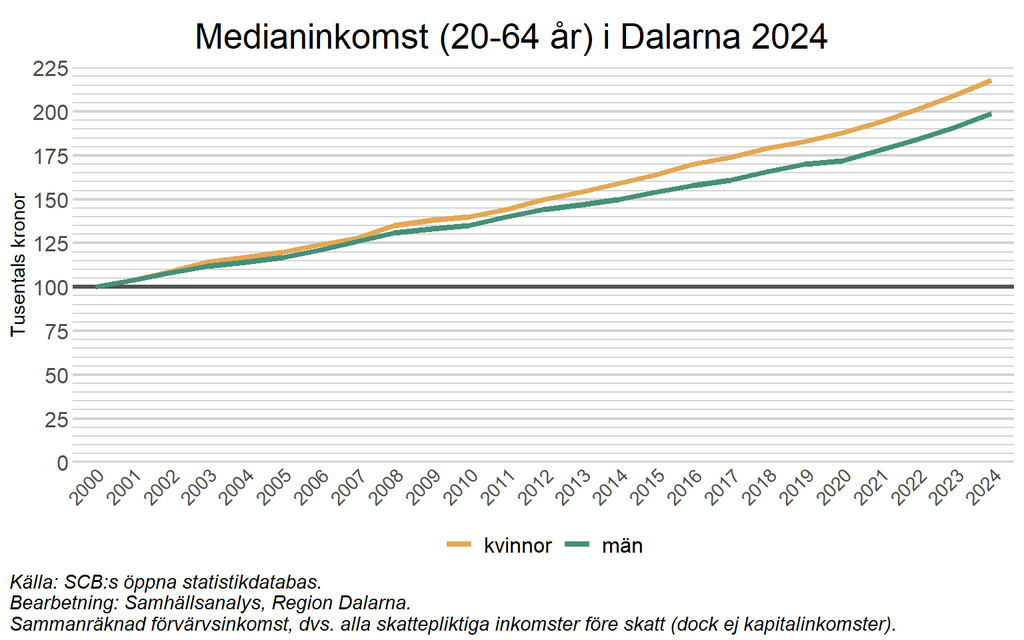

### Export

**Regional varuexport och utländska besökare skapar regional export**

*Varuexport*

Dalarnas export är en viktig motor för länets ekonomi och skapar värden långt utanför den lokala marknaden. När företag i Dalarna säljer varor och tjänster internationellt ökar intäkterna i länet och ger utrymme för investeringar, innovation och fler jobb. Dalarnas export handlar både om varor och tjänster som säljs utanför landsgränsen och utländska besökare som gästar Dalarna och konsumerar i länet.

Dalarnas omfattande industri är också en nyckel till möjligheter att bidra till den gröna omställningen både regionalt och globalt.

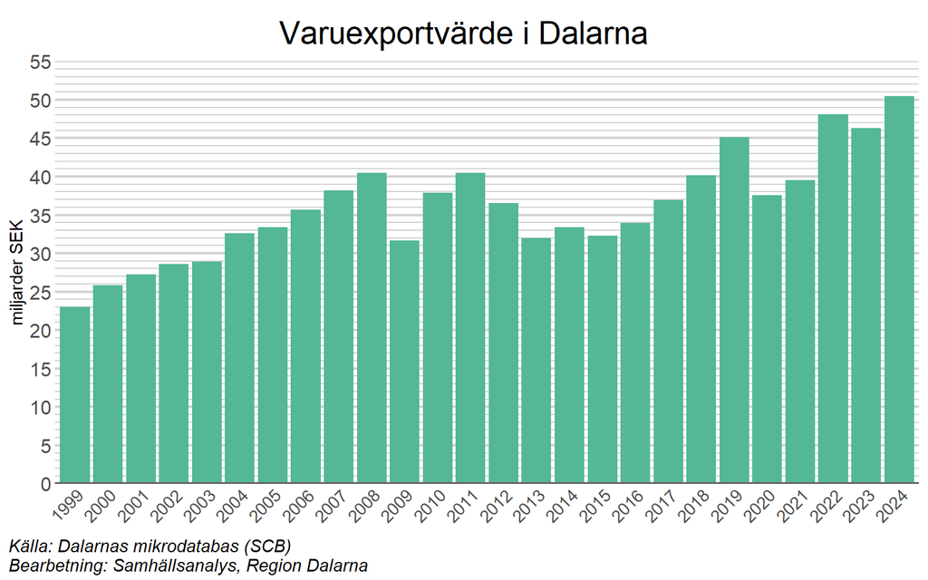

I diagrammet nedan redovisas mottagarländer för export från Dalarna i storleksordning. De största mottagarländerna för Dalarnas export år 2024 var Tyskland, USA och Norge som tillsammans stod för ungefär 30 procent av exportvärdet.

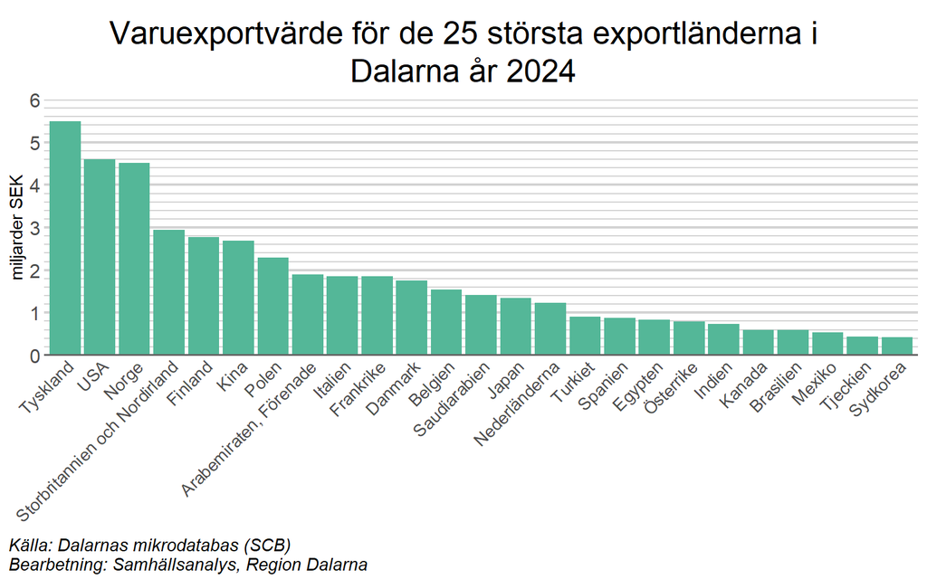

*Utländska besökare*

Antalet utländska besökares gästnätter är en del av det samlade exportvärdet då det för in pengar utomlands ifrån till Sverige och Dalarna. Under 2010-talet har antalet gästnätter varit relativt konstant runt 700 000, för att under pandemin minska avsevärt av naturliga skäl. Efter pandemin ses en kraftig ökning och under 2025 passerades miljonstrecket i antal gästnätter av utländska besökare.

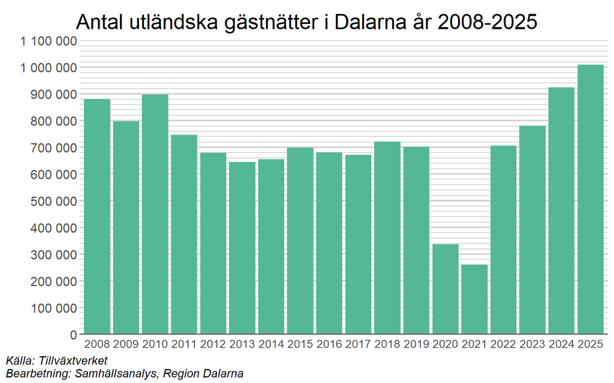

# 3 Ett sammanhållet Dalarna

I ett sammanhållet Dalarna finns goda livsmiljöer som skapar en känsla av närhet. Det är ett Dalarna fyllt av engagemang, där människor upplever delaktighet och tillsammans bidrar till en hållbar utveckling. Det är ett inkluderande, jämställt, och jämlikt Dalarna där människor mår bra och där alla ges möjlighet att utvecklas.

Den sociala dimensionen av hållbarhet i det regionala utvecklingsarbetet handlar om att alla människor, utifrån sina behov och förutsättningar, ges likvärdiga möjligheter att delta och bidra i samhällsutvecklingen. Ju fler som känner sig delaktiga desto mer utveckling kan åstadkommas, och samhällsekonomiska kostnader minskas.

I målområdet Ett sammanhållet Dalarna bygger vi ett län där goda livsmiljöer skapar en känsla av närhet – oavsett om man bor i stad, tätort eller landsbygd. Det handlar om ett Dalarna fyllt av engagemang och delaktighet, där människor tillsammans bidrar till hållbar utveckling och god beredskap.

## 3.1 Dalfolkets hälsa, trygghet och tillit

Dalfolkets hälsa, trygghet och tillit är centrala för ett hållbart och sammanhållet Dalarna – och påverkar både livskvalitet, arbetskraftens förutsättningar och samhällsgemenskap. I det här avsnittet beskriver vi utvecklingen med hjälp av indikatorer som fångar både långsiktiga och mer vardagsnära villkor: medellivslängd och upplevd hälsa ger en övergripande bild av hur människor mår, medan folksjukdomar belyser de stora, långvariga hälsoutmaningarna och hur de fördelar sig i befolkningen. Vi kopplar detta till trygghet och brott mot person, som påverkar hur människor rör sig och deltar i samhället, samt till tillit – förtroendet för andra människor och för samhällsinstitutioner – som är en nyckel till gemensam handlingskraft och motståndskraft vid förändring och kris.

Mer finns att läsa här, [“folkhälsa på Region Dalarnas hemsida”](https://www.regiondalarna.se/om-oss/hallbar-utveckling/social-hallbarhet/folkhalsa/).

Medellivslängd ➡  
Medellivslängden ökar, men inte för lågutbildade kvinnor. Ensamboende har en lägre medellivslängd än sammanboende.

Hälsa och folksjukdomar➡  
Vuxna skattar sin hälsa något sämre och ungdomar skattar hälsan tydligt sämre jämfört med tidigare år. Incidens av hjärtinfarkter minskar men andelen överviktiga ökar. Fallskador bland äldre ökar något.

Trygghet och brott ➡  
Andelen som avstår från att gå ut ensam är oförändrad, ungdomars upplevelse av rasism i skolan ökar. Stora skillnader i anmälda brott mellan kommunerna.

Tillit ➡  
Andelen som uppger att de saknar tillit andra ökar något.

### Medellivslängd

**Medellivslängd i relation till utbildning**

Medellivslängd är ett tydligt mått på samhällsutveckling och välfärd. Sverige har bland de högsta medellivslängderna i världen och Över tid syns fortfarande en svagt positiv utveckling i de flesta grupper, särskilt bland dem med gymnasial och eftergymnasial utbildning, och kvinnor har genomgående en högre återstående medellivslängd än män när man tittar på exempelvis utbildningsgrupper. Medellivslängd går att mäta på flera sätt, men ett vanligt mått är hur många år en 30-åring i genomsnitt förväntas leva ytterligare.

För grupper med förgymnasial utbildning är utvecklingen mer ojämn, och bland män syns en mindre nedgång kring slutet av 2010-talet/början av 2020-talet följt av återhämtning, medan gruppen kvinnor det senaste året visar på en nedgång. Sammantaget illustrerar diagrammet att utbildning hänger tydligt samman med livslängd, och att skillnaderna är stabila över perioden.

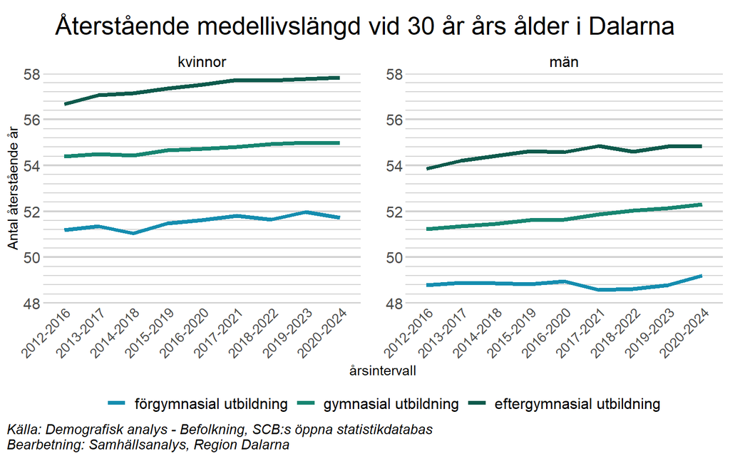

En fördjupning av analysen om vad som bidrar till en högre medellivslängd som gjorts på nationell nivå av SCB visar att även boenderelation har stor betydelse [“SCB”](https://www.scb.se/hitta-statistik/statistik-efter-amne/befolkning-och-levnadsforhallanden/befolkningens-sammansattning-och-utveckling/demografisk-analys/pong/statistiknyhet/livslangd-efter-utbildningsniva/). Sammanboende män och kvinnor lever längre än ensamstående män och kvinnor i respektive utbildningsgrupp. För gruppen män är skillnaden så pass stor att sammanboende män med förgymnasial utbildning lever i genomsnitt längre än ensamstående män med eftergymnasial utbildning.

### Hälsa och folksjukdomar

**En god upplevd hälsa och folksjukdomar**

*En god upplevd hälsa*

En god hälsa är en viktig förutsättning för att utvecklas och vara en aktiv samhällsmedborgare. I Dalastrategin lyfts att jämlika livsvillkor och god hälsa är viktiga för att ge alla människor i Dalarna möjlighet att utvecklas.

Folkhälsan mäts genom enkätundersökningar där ett urval av befolkningen (16-84 år) får besvara frågor bland annat om hur de upplever sin hälsostatus. Det är Folkhälsomyndigheten som undersöker folkhälsan och dess förutsättningar. Då materialet baseras på enkätsvar ska mindre förändringar och skillnader mellan grupper bedömas med försiktighet.

Av svaren framgår att hälsan varierar både i riket och mellan platser i Dalarnas län. Personer med lägre utbildningsnivå uppger generellt sett en sämre hälsa och sämre förutsättningar för en god hälsa än de med högre utbildningsnivå.

År 2024 var det ungefär 65 procent av respondenterna i Dalarnas län som uppgav ett bra eller mycket bra allmänt hälsotillstånd, vilket var en tydlig försämring jämfört med åren innan. Under tidsperioden 2014-2021 var det allmänna hälsotillståndet i länet stabilt runt 68-69 procent utan några större förändringar. Under samtliga fyra uppmätta år har en något större andel av männen svarat att de upplever ett allmänt gott hälsotillstånd i jämförelse med andelen kvinnor, en skillnad som ökade 2024.

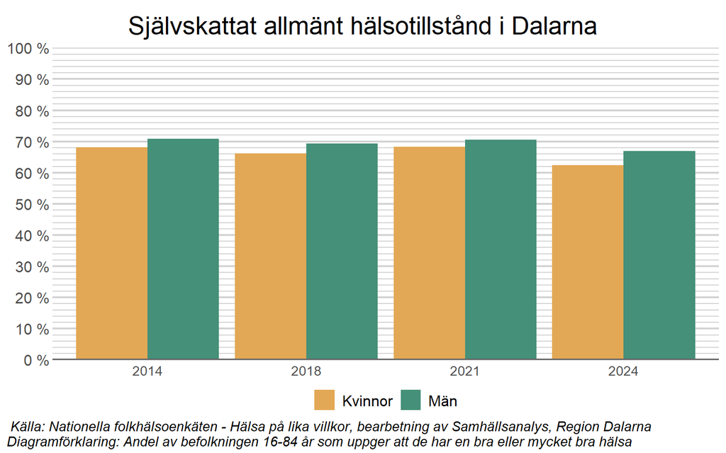

I ett nationellt perspektiv ligger alla kommuner i Dalarnas län i nivå med, eller under riksgenomsnittet. I 2024 års undersökning uppgav ca 68 procent av befolkningen i riket att de har ett bra eller mycket bra allmänt hälsotillstånd, samma andel som Leksands invånare rapporterade, medan genomsnittet för Dalarnas befolkning var 65 procent, det vill säga 4 procentenheter under riksgenomsnittet. Lägst nivå på andelen med självrapporterad god hälsa finns i Säter där ungefär 60 procent av invånarna ansåg sig ha en allmänt god hälsa.

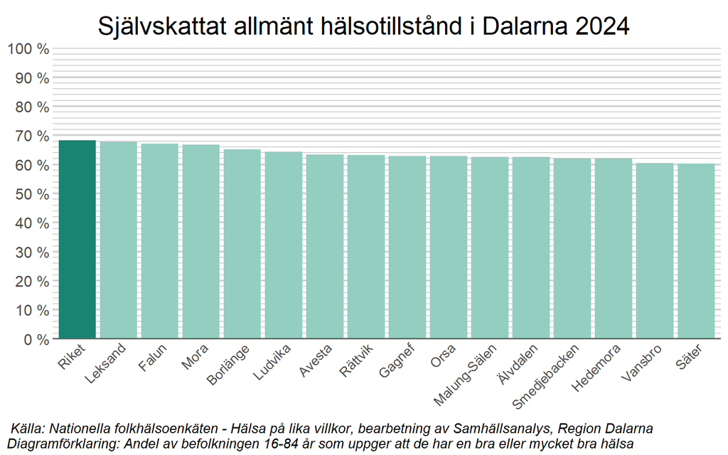

I Folkhälsomyndighetens enkätundersökning finns även frågor om upplevd psykisk påfrestning. I Dalarna svarar en ungefär lika stor andel kvinnor och män, cirka 10 procent, att de har erfarit allvarlig psykisk påfrestning det senaste året. Andelen har minskat något mellan mätåren 2022 och 2024.

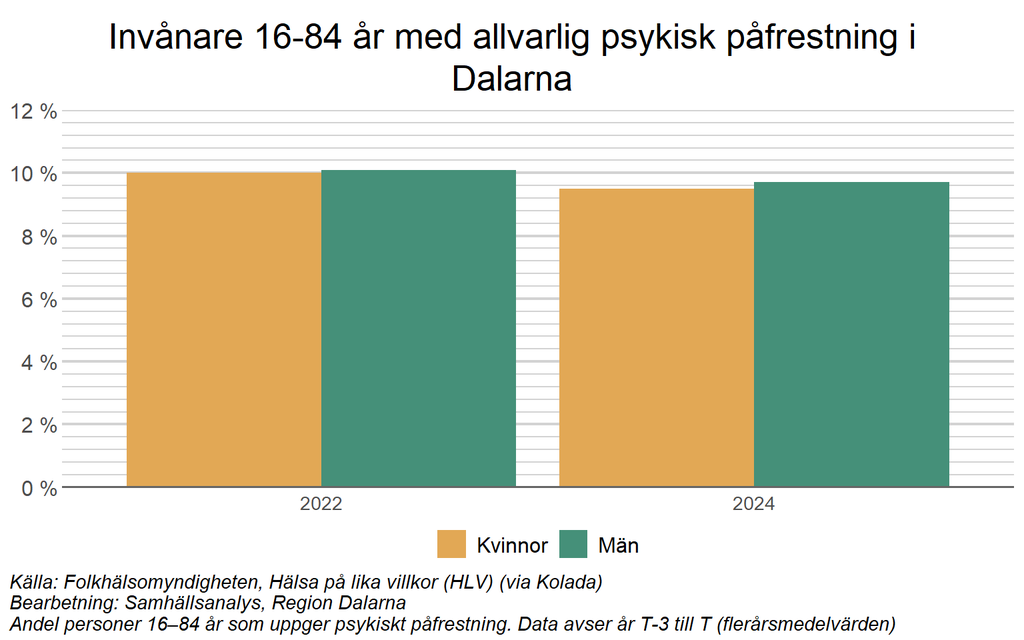

I en nationell jämförelse ses att skillnaderna är större mellan kvinnor och män för de flesta län och för riket. Kvinnor i Dalarna har till lägre grad uppgett att de erfarit allvarlig psyisk påfrestning, medan män i Dalarna i högre grad än riksgenomsnittet uppgett att de erfarit detsamma.

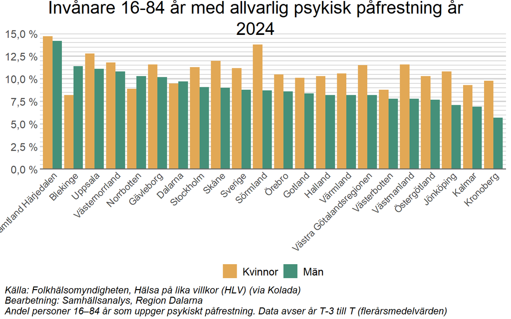

I Folkhälsomyndighetens undersökning ingår inte ungdomar. Däremot frågas om ungdomars mående genom enkätundersökningen LUPP (lokal uppföljning av ungdomspolitiken), som genomförs på både högstadiet och gymnasiet vart tredje år. I diagrammet nedan ses en försämring i skattad hälsa bland både tjejer och killar över tid.

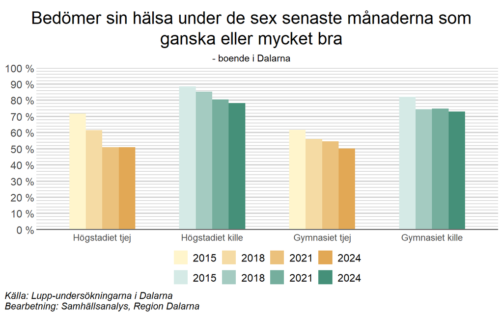

*Folksjukdomar*

Några vanliga folksjukdomar och hälsorisker i befolkningen är hjärtinfarkt, övervikt och fallskador bland äldre. Tillsammans ger indikatorerna en bild av både livsstilsrelaterade risker och skador som påverkar hälsa, livskvalitet och behovet av vård och omsorg. Genom att följa utvecklingen över tid och skillnader mellan grupper och geografier kan vi se var förebyggande insatser behövs mest – till exempel kring levnadsvanor, tryggare boendemiljöer och fallförebyggande arbete för äldre.

I diagrammen nedan visas förekomst av hjärtinfarkter uppdelat efter kön i Dalarna mellan åren 2004 - 2023. Över tid minskar förekomsten per 100 000 invånare i båda grupperna, i båda grupperna har förekomsten nästan halverats. Men könsskillnaderna är markanta, förekomsten bland män är nästan dubbelt så hög som bland kvinnor.

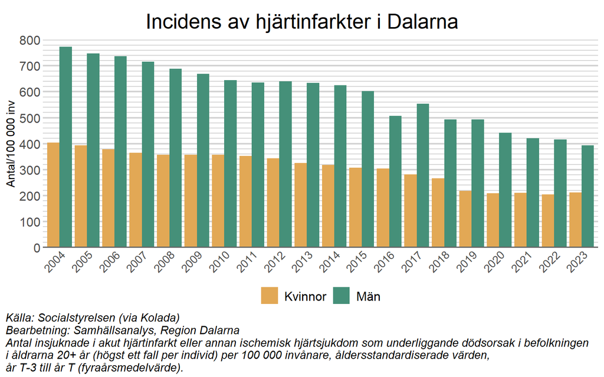

En jämförelse med övriga regioner i riket visar att könsmönstret är detsamma i samtliga regioner, och att Dalarna ligger lite över riksgenomsnittet för både kvinnor och män när det gäller förekomst per 100 000 invånare.

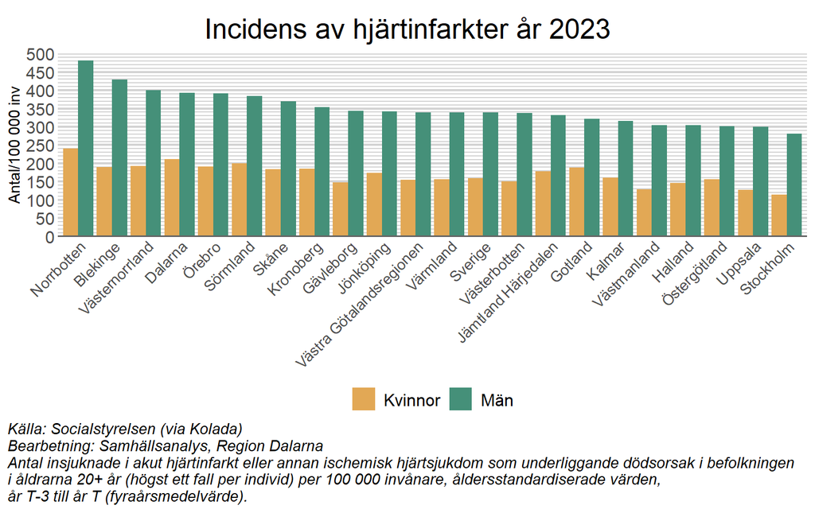

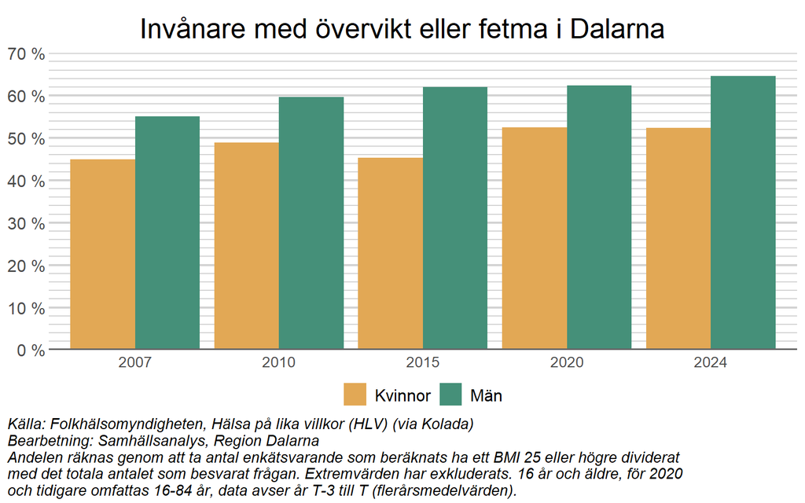

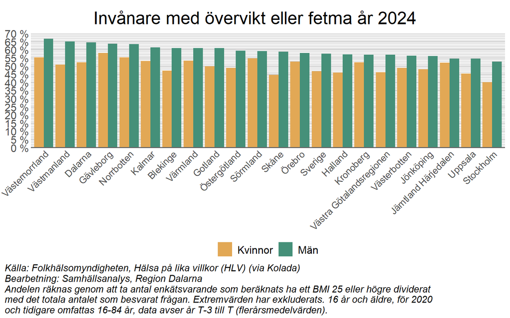

I diagrammet visas fallskador bland personer 65 år och äldre med ett 3-års medelvärde i antal per 100 000 invånare i Dalarna.

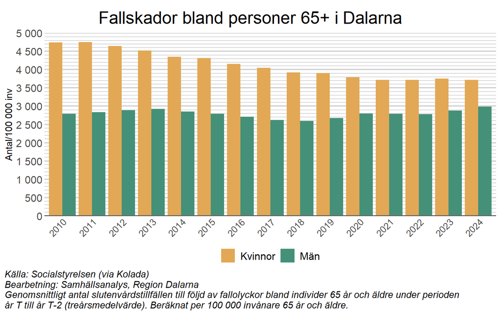

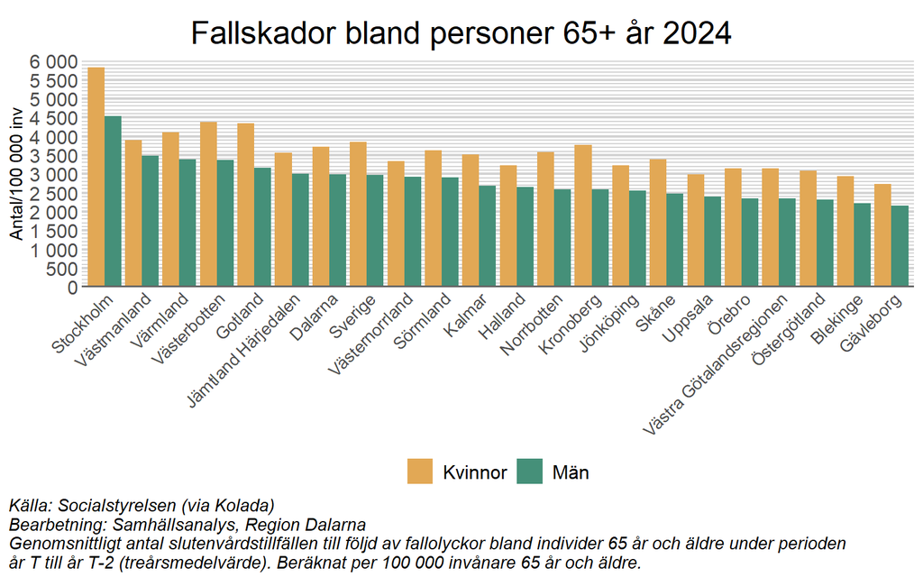

### Trygghet och brott

**Upplevd trygghet och brott mot enskilda**

*Upplevd trygghet*

I diagrammet nedan visas andelen som i Folkhälsomyndighetens enkätundersökning svar att de avstår från att gå ut ensam av rädsla för att bli överfallen, rånad eller på annat sätt ofredad.

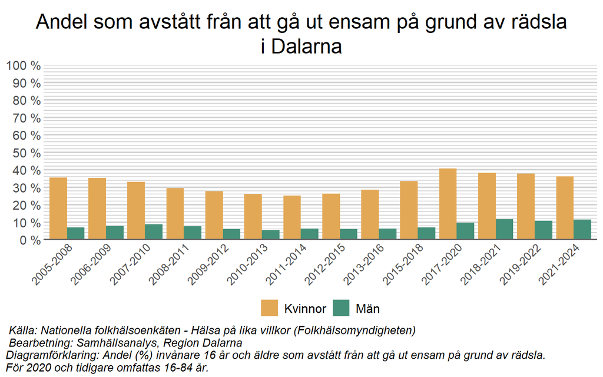

I ungdomsenkäten LUPP, ställs frågor till eleverna om de tycker att det stämmer helt eller till stor del att rasism förekommer på skolan, på högstadiet respektive gymnasiet, i diagrammet nedan visas resultatet.

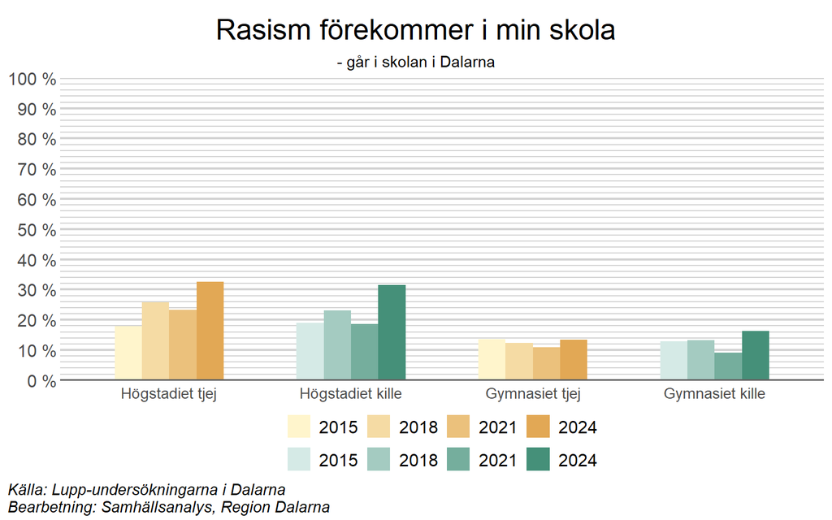

*Brott mot enskilda*

Här följer digram över anmälda brott mot enskilda så sombostadsinbrott, misshandel, sexualbrott och våldsbrott.

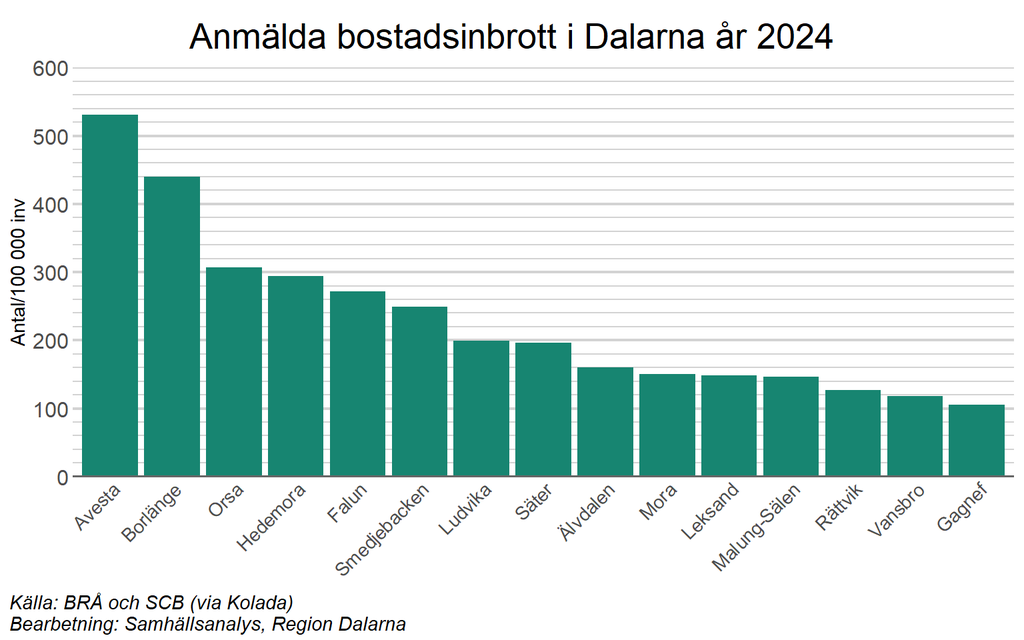

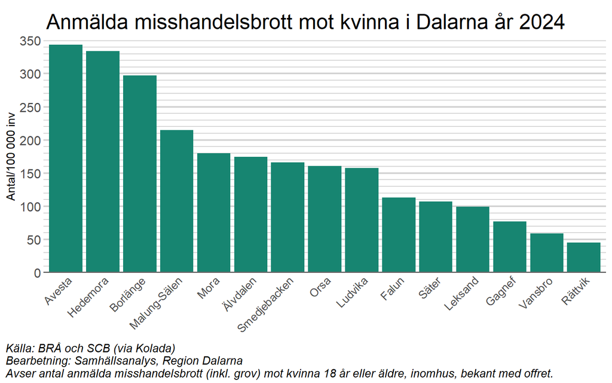

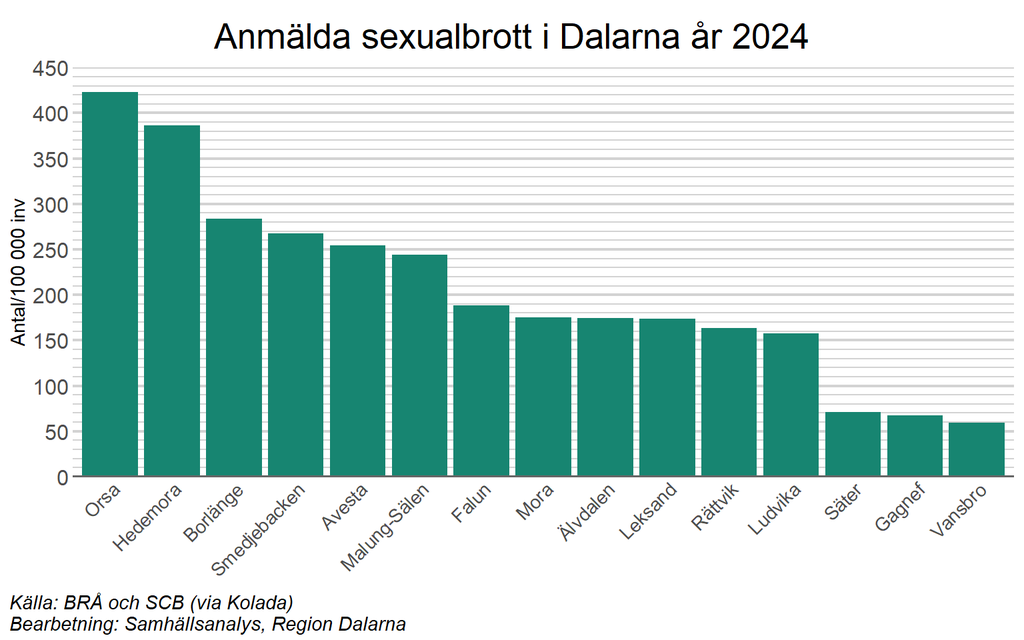

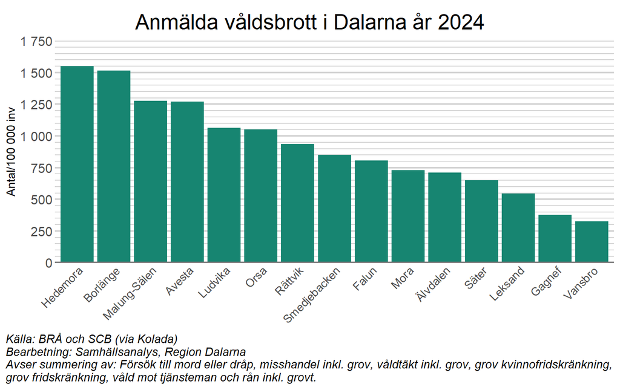

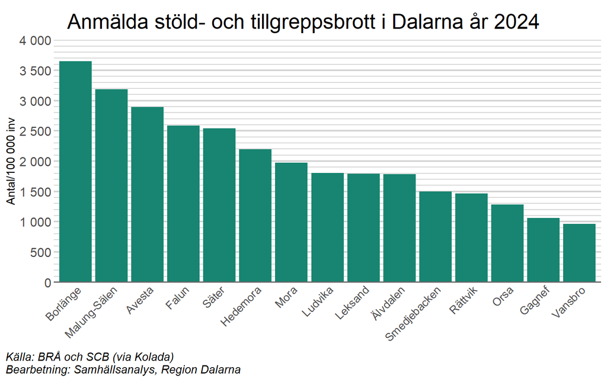

### Tillit

**Tillit till varandra**

Det är människorna i Dalarna som skapar regionen – alla enskilda individer boende i länet, som också är del av familjer, organisationer, företag och andra gemenskaper. Människors känsla av sammanhang och delaktighet är centralt för att skapa ett väl fungerande samhälle. För att skapa sammanhang och delaktighet behövs tillit mellan dem som ingår i gemenskapen, och det behövs sätt att hantera osäkerhet som kan uppstå när nya medlemmar inkluderas i en gemenskap. Socialt kapital beskriver det kitt som uppstår när en grupp människor enas kring gemensamma värden, normer och värderingar, det får människor att ha tillit till sina medmänniskor och till det gemensamma. Att den representativa demokratins institutioner, såsom kommuner, region och myndigheter, är väl fungerande och att invånarna har förtroende för dem är centralt för en levande demokrati. En stark tillit till andra underlättar samarbetet mellan människor och viljan och förmågan att bidra med nya idéer till samhällsutvecklingen. Ett samhälle med ett starkt socialt kapital är bättre rustat för att möta förändringar och eventuella kriser.

Tillit är i stort en fråga om människors upplevelse och mäts bland annat genom enkätundersökningar. Folkhälsomyndigheten gör regelbundet enkätundersökningar med sådana frågor och i diagrammet nedan ses resultatet för hur stor andel av invånare 16-84 år som svarat att de anser sig sakna tillit till andra. Värdet är beräknat som medelvärdet över en fyraårsperiod. Mellan tidsperioden 2004-2007 och 2021-2024 visar det sig att andelen som anser sig sakna tillit har ökat något, från 28 procent till 29 procent. Under tidsperioden har andelen gått från att andelen kvinnor som saknar tillit till andra har varit högre än andelen män som saknar tillit till andra, fram till ungefär år 2015. Sedan år 2015 är mönstret inte längre entydigt, och det senaste året 2024 uppgav en större andel män, än kvinnor, att de saknade tillit till andra.

Andelen som säger sig sakna tillit utgör ungefär 29 procent av invånarna, samtidigt som det framkommer i folkhälsoenkäten att ca 20 procent av invånarna aldrig eller väldigt sällan deltagit i sociala sammankomster före pandemin, och att andelen har ökat till ca 35 procent av invånarna efter pandemin år 2022. Att delta i olika typer av sociala sammankomster är en byggsten för att skapa sammanhang och i förlängningen tillit.

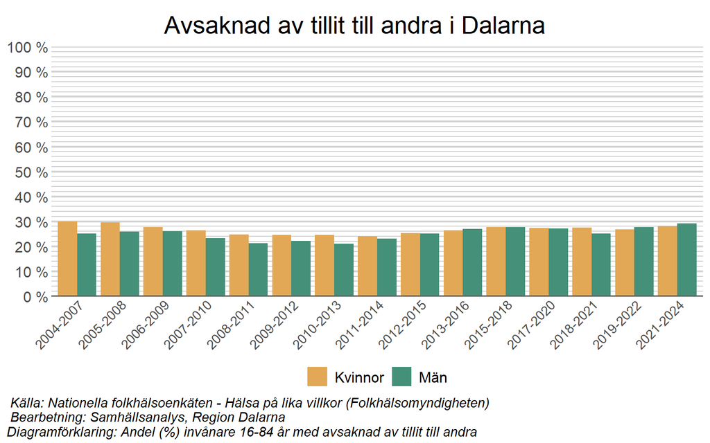

## 3.2 Dalfolkets delaktighet och samhällsengagemang

Dalfolkets delaktighet och samhällsengagemang är en grund för både demokrati och hållbar samhällsutveckling. I det här avsnittet följer vi hur förutsättningarna ser ut för att kunna vara med och påverka – och för att vilja engagera sig. Valdeltagande och upplevelsen av att kunna påverka samhället visar hur stark den demokratiska delaktigheten är, medan deltagande i kultur- och fritidsaktiviteter speglar social gemenskap, folkhälsa och sammanhållning i vardagen. Samtidigt hänger engagemang nära ihop med tillgänglighet: bredband möjliggör delaktighet i digitala tjänster och samhällsinformation, och närhet till skola och matbutik påverkar både livskvalitet och möjligheten att bo och verka i hela länet. Tillsammans ger indikatorerna en bild av hur Dalarna kan stärka delaktigheten genom både demokratiska arenor och jämlika livsvillkor.

Valdeltagande och samhällsengagemang ➡  
Valdeltagandet sjunker något, ungdomars vilja att påverka i sin kommun sjunker markant.

Kultur och fritid ➡  
Andel elever i kulturskolan skiljer sig mellan kommunerna, som mest var 5:e ung till var 10:e ung. Aktiva låntagare vid biblioteken skiljer sig också, den nationella trenden är nedåtgående.

Butik, skola och bredband ➡  
Tillgången till butik, skola och bredband är oförändrad.

### Valdeltagande och samhällsengagemang

**Valdeltagande och ungas vilja att påverka**

En levande demokrati grundar sig i människors tillit till att de demokratiskt valda representativa institutionerna fungerar, såsom kommuner, region och myndigheter. Valdeltagande och viljan att vara med och påverka i sin hemkommun är därmed en viktiga indikator på invånarnas vilja och tro på de demokratiska institutionerna i länet.

*Valdeltagande*

I Dalarna har valdeltagandet varierat över tid. I riksdagsvalet valde år 1973 drygt 90 procent att rösta, en andel som hade minskat avsevärt till valet 2002, då bara ungefär 78 procent valde att rösta i riksdagsvalet. Därefter ökade valdeltagandet stadigt i de nationella valen fram till 2018, då 88 procent av invånarna i Dalarna röstade i riksdagsvalet. I valet 2022 minskade valdeltagandet dock tydligt. Generellt är valdeltagandet ungefär lika högt i såväl riksdagsval, som val till region- och kommunfullmäktige, även om det på senare år har varit något högre i riksdagsvalet.

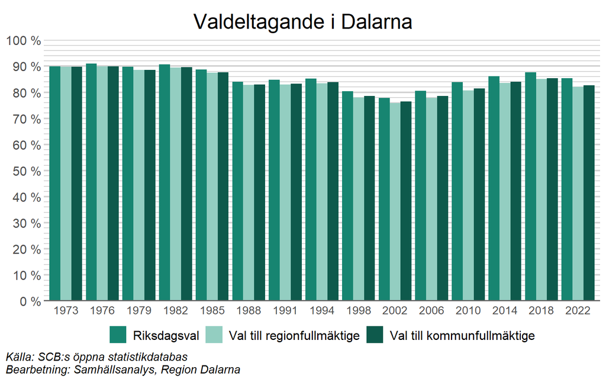

*Ungas vilja att påverka*

I diagrammet nedan ses andelen unga som i en enkät som genomförs regelbundet via skolan svarat att de vill vara med och påverka. Trenden mellan 2015 och 2024 visar tydligt på att både killar och tjejer i allt lägre grad vill vara med och påverka i frågor som rör deras kommun.

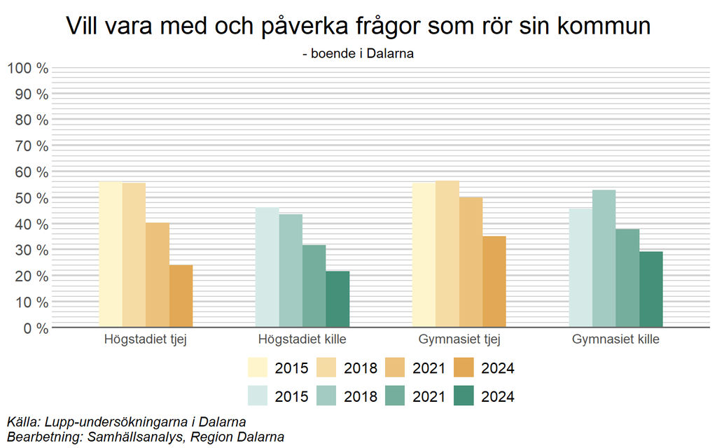

### Kultur och fritid

**Kulturskola och bibliotekslån**

*Elever i kulturskolan*

Kultur- och fritidsaktiviteter är viktiga för samhällsutvecklingen och särskilt för ungdomars utveckling. Mer statistik om civilsamhället och befolkningens engagemang skulle vara önskvärt men här redovisar vi några av de uppgifter som finns tillgängliga.

För Dalarna finns statistik över elevantalet i åtta av länets 15 kommuner. Störst andel elever utgörs av flickor i Malung-Sälen, där cirka 30 procent av flickorna går i musik- eller kulturskolan, och 10 procent av pojkarna. Falun och Avesta har lägst andel av de rapporterade kommunerna, där ungefär 13 procent av flickorna och ungefär 7 procent av pojkarna går i musik- eller kulturskola.

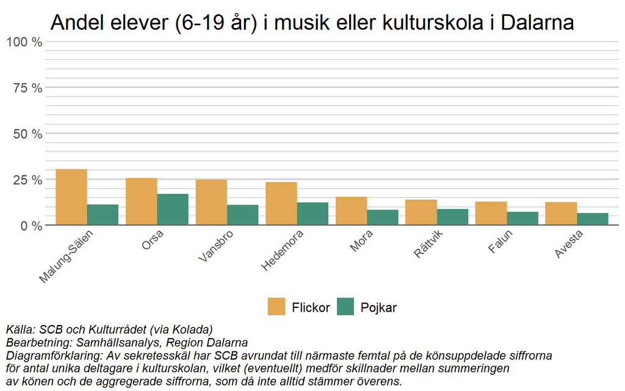

*Aktiva låntagare på Dalarnas bibliotek*

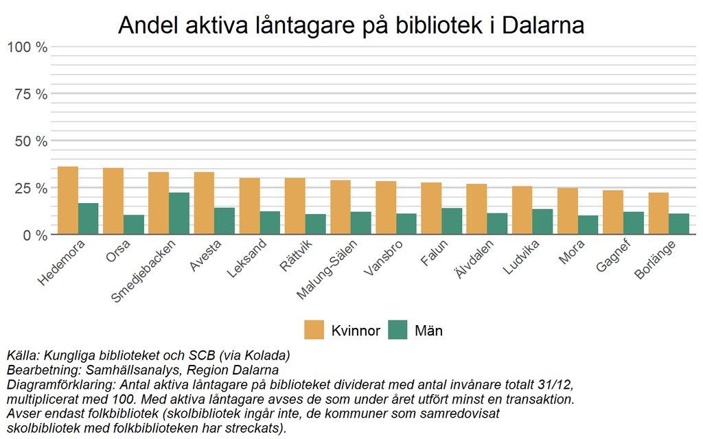

### Butik, skola och bredband

**Tillgång till butik, grundskola och bredband**

*Tillgång till butik och grundskola*

Olika platser i Dalarna har olika utmaningar och möjligheter att möta de förändrade behoven. En princip för genomförandet av Dalastrategin är att allt utvecklingsarbete ska vara platsbaserat med målsättningen att sammanhållningen ska stärkas och olika platsers förutsättningar och resurser ska tas till vara på ett bra sätt. För utvecklingskraft i hela länet är det viktigt att säkra tillgången till service, vård, fritidsaktiviteter och kultur i alla delar av länet. Tillgången till service påverkar människors levnadsvillkor och är viktig för platsens attraktivitet och för möjligheten att skapa arbetstillfällen lokalt. Den här indikatorn presenterar flera olika mått på tillgång till service; tillgång till grundskola och tillgång till dagligvarubutik samt upplevd tillgång till vård.

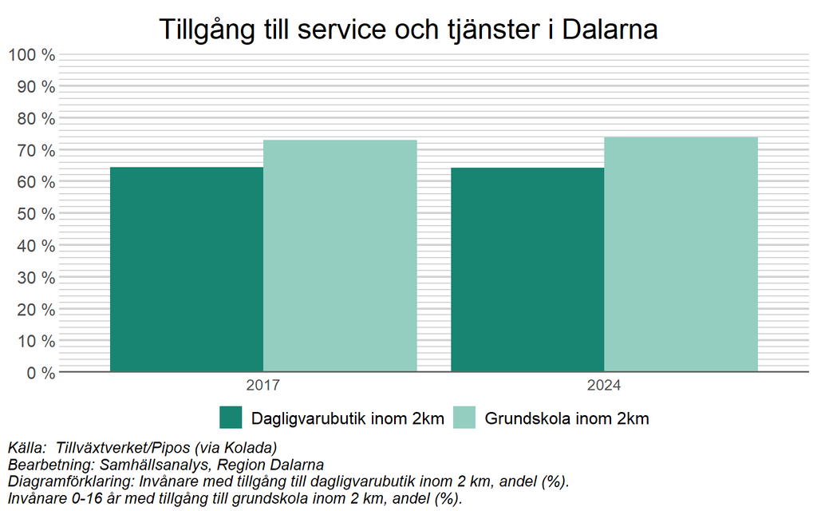

Tillgång till vård mäts genom en enkätundersökning, där invånarna tillfrågas om deras upplevda tillgång till vård. Som ses i diagrammet nedan så har andelen som säger sig ha tillgång till den vård de behöver ökat över tid, och både 2024 och 2025 har cirka 90 procent av både kvinnor och män svarat att de instämmer i att de har tillgång till den vård de behöver.

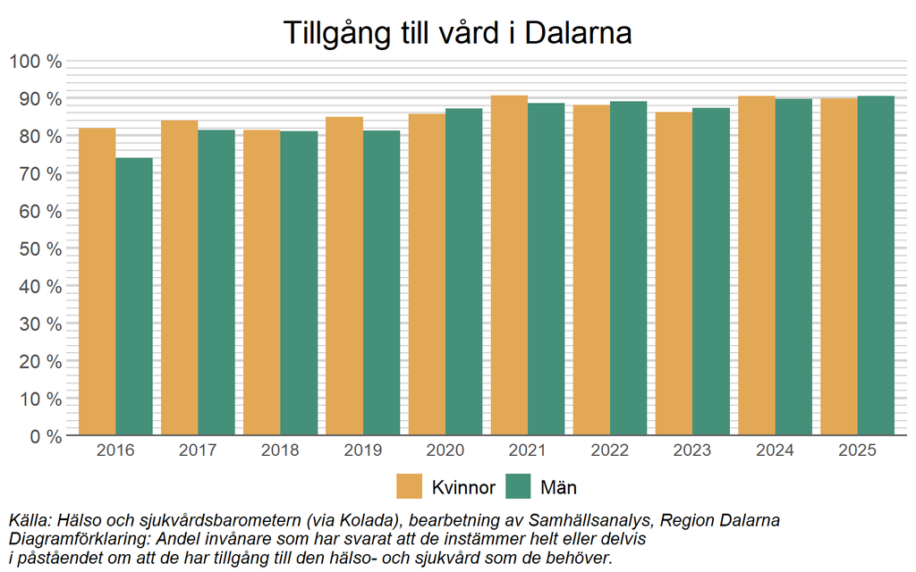

*Tillgång till bredband*

Tillgång till en snabb och robust digital infrastruktur är för de flesta en grundförutsättning för att bo och verka i hela Dalarna. Fysiska och digitala mötesplatser gör att vi når både varandra och omvärlden. En av utmaningarna för Dalarna är en ojämnt fördelad digital infrastruktur. Att stärka och tillgängliggöra den digitala infrastrukturen för hela Dalarnas befolkning, oavsett plats, är avgörande för en lyckad digitalisering av samhället.

I Dalarna har andelen hushåll med tillgång till, eller möjlighet att ansluta till, bredband om minst 1 Gbit/s ökat från ca 75 procent 2017 till ca 97 procent 2024. Det kan jämföras med riksgenomsnittet som år 2024 var 99 procent.

Som synes så har andelen hushåll minskat något mellan åren 2023 och 2024. Det förklaras med att den data som statistiken bygger på blivit bättre. Post- och telestyrelsen har skärpt kraven på nätägarna att rapportera korrekta uppgifter om de hushåll som är kommersiellt möjliga att ansluta. Som synes har en del nätägare under 2023 överskattat antalet hushåll.

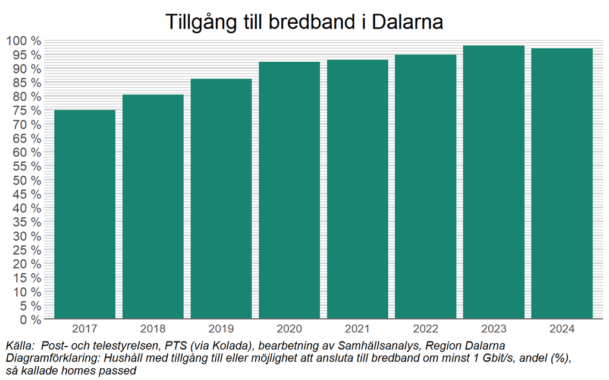

## 3.3 Ekonomisk jämlikhet och ojämlikhet

Ekonomisk jämlikhet är en viktig grund för både social hållbarhet och ekonomisk utvecklingskraft. I det här avsnittet belyser vi hur resurser och livsvillkor fördelas i Dalarna genom tre centrala mått: gini-koefficienten, som visar graden av inkomstojämlikhet i befolkningen, andel barn i ekonomisk utsatthet, som fångar hur många barn som växer upp med begränsade ekonomiska förutsättningar, samt mottagare av sociala ersättningar, som speglar behovet av ekonomiskt stöd och försörjningsstöd i olika grupper. Tillsammans ger indikatorerna en samlad bild av både skillnader i inkomster och var ekonomisk sårbarhet är som störst – och kan användas för att följa utvecklingen över tid och rikta insatser dit de gör mest nytta.

Inkomstfördelning ➡  
Inkomstfördelningen är oförändrad, i Dalarna är den mer jämlik än i riket.

Barn i ekonomisk utsatthet ➡  
Andel invånare 0-19 år som bor i hushåll med låg ekonomisk standard är oförändrad.

Bidragsmottagare ➡  
Det totala antalet utbetalade bidragsår minskar.

### Inkomstfördelning

I Dalastrategin lyfts ekonomiska klyftor som en framtidsutmaning för länet.

Ekonomiska klyftor mellan olika grupper i samhället är en utmaning för både Sverige och Dalarna. Om de socioekonomiska klyftorna blir alltför stora riskerar de att motverka sammanhållning, tillit och trygghet. Det riskerar i sin tur att försvaga demokratin, exempelvis genom systematiska skillnader i valdeltagande, faktiskt eller upplevt inflytande samt delaktighet och engagemang.

För att redovisa ojämlikheten i inkomstfördelningen används gini-koefficienten. Ett högt värde på koefficienten visar på större inkomstskillnader och därmed större ojämlikhet. Här redovisas ginikoefficienten beräknad genom disponibel inkomst och hänsyn tagen till hur hushållet som individen bor i är sammansatt. Det betyder att beräkningen beaktar om personen är ensamboende eller sammanboende och om den har ansvar för minderåriga barn eller inte etc, faktorer som kan minska eller öka individens disponibla inkomst.

I Dalarna har ginikoefficienten ökat något från 2011 till 2024, vilket således visar på en ökad ekonomisk ojämlikhet i länet, med en toppnotering 2019. Värt att notera är dock att trenden verkar bruten då ginikoeffiecienten minskade såväl 2023 som 2024, jämfört med åren innan. Ginikoefficienten för länet ligger även under koefficienten för riket för samtliga år förutom 2019, det vill säga i Dalarna är inkomsterna mindre ojämlika än i Sverige som helhet. År 2019 avviker så skarpt från den generella trenden att det årets notering bör betraktas med försiktighet.

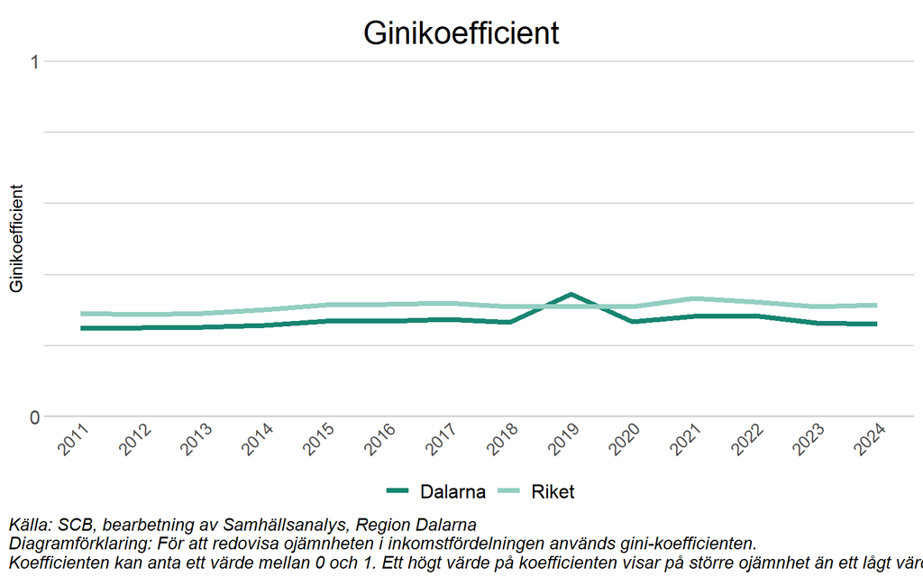

### Barn i ekonomisk utsatthet

Barn är särskilt utsatta då de inte kan påverka sin livssituation utan är beroende av sina omsorgspersoner och vårdnadshavare. Som låg ekonomisk standard klassas hushåll som har en årsinkomst under 60 procent av medianvärdet för hushållens årliga inkomster i Sverige. Andel barn som lever i hushåll med låg ekonomisk standard blir därför ett mått på barns ekonomiska utsatthet i samhället.

I diagrammet nedan kan vi notera att andelen unga (0-19 år) som lever i hushåll med låg ekonomisk standard i Dalarnas län har ökat över mätperioden, vilket är negativt, från 18 procent år 2011 till drygt 20 procent 2024. Viktigt att notera är dock att andelen har minskat tydligt mellan 2019 och 2024, från 23 procent till 20 procent.

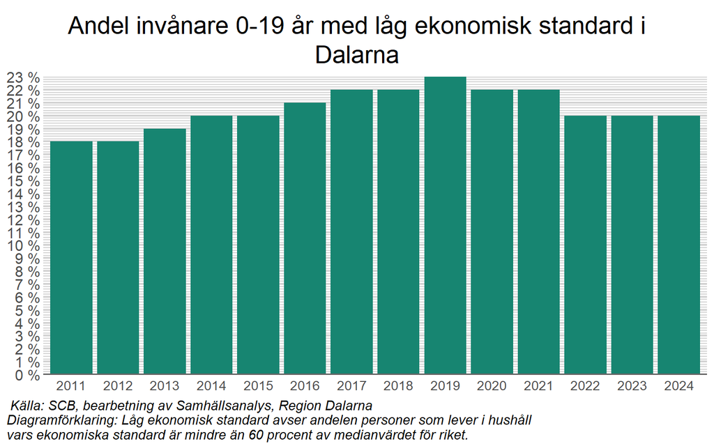

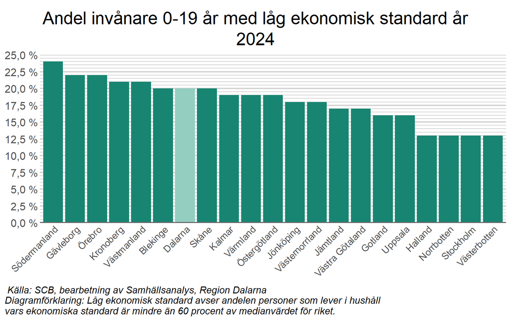

### Bidragsmottagare

Ett annat mått att följa för att utröna hur den ekonomiska jämlikheten utvecklas är andelen av befolkningen som mottar någon form av sociala ersättningar eller bidrag för att försörja sig. Det handlar om ersättningar som sjukpenning, sjuk- och aktivitetsersättning, a-kassa, ekonomiskt bistånd, etableringsersättning och arbetsmarknadsåtgärder och för att få ett jämförbart värde har ersättningarna räknats om till helårsbidrag (helårsekvivalenter). Sedan 2014 har antalet helårsekvivalenter sammanlagt minskat från cirka 25 000 till cirka 17 500. Således är de som försörjer sig genom bidrag i Dalarna allt färre till antalet och signalerar att fler har andra inkomster.

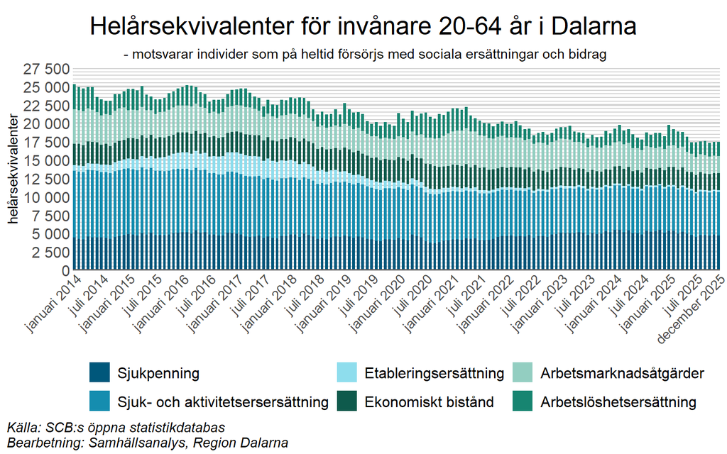